# Random Forest Problem Set

Your Name Here

# 1 Introduction

This problem set corresponds to the chapter on classification and regression trees and random forests in the course https://jacobshermansd.github.io/parametric-trades. In this problem set, you’ll first perform regression using a regression tree and a random forest on the [Student Performance](https://archive.ics.uci.edu/ml/datasets/Student+Performance) data set. Then you will perform classification using a random forest on the Glass data set (the same data set used in the support vector machine problem set). Both data sets are available from the University of California - Irvine’s Machine Learning Repository.

The solutions for this problem set use the following packages; however, you may use whatever packages you prefer.

- `rpart`
- `tidyverse`
- `randomForest`

# 2 Regression

The student performance data set is a zip file, so it’s a little trickier to download than a .csv file. This code will do the trick.

```
# create an empty temporary file
# temp <- tempfile()

# download the target file to the temp file
# download.file("https://archive.ics.uci.edu/ml/machine-learning-databases/00320/student.zip",temp)

# read the data from one of the unzipped files
# sp <- read.csv(unzip(temp, "student-mat.csv"), sep=';', stringsAsFactors = TRUE)

# delete the temporary file
# unlink(temp)

# remove the temp variable from the name space
# rm(temp)
```

```r
# create an empty temporary file
temp <- tempfile()

# download the target file to the temp file
download.file("https://archive.ics.uci.edu/ml/machine-learning-databases/00320/student.zip",temp)

# read the data from one of the unzipped files
sp <- read.csv(unzip(temp, "student-mat.csv"), sep=';', stringsAsFactors = TRUE)

# delete the temporary file
unlink(temp)

# remove the temp variable from the name space
rm(temp)
```

The data consists of 395 observations of 33 predictors. The first 30 columns are all information about the students including demographic, social, and school-related features. The last three columns are the student’s grades in a math class. It’s not completely clear, but I assume the grades are from a one-term math class broken into thirds and that`G1` is the grade received after midterm #1, `G2` is the grade after midterm #2, and `G3` is the final grade. The predictor variables are explained at the link to the website above, but also use `str()` to get a feel for the data.

```r
str(sp)
```

```
## 'data.frame':    395 obs. of  33 variables:
##  $ school    : Factor w/ 2 levels "GP","MS": 1 1 1 1 1 1 1 1 1 1 ...
##  $ sex       : Factor w/ 2 levels "F","M": 1 1 1 1 1 2 2 1 2 2 ...
##  $ age       : int  18 17 15 15 16 16 16 17 15 15 ...
##  $ address   : Factor w/ 2 levels "R","U": 2 2 2 2 2 2 2 2 2 2 ...
##  $ famsize   : Factor w/ 2 levels "GT3","LE3": 1 1 2 1 1 2 2 1 2 1 ...
##  $ Pstatus   : Factor w/ 2 levels "A","T": 1 2 2 2 2 2 2 1 1 2 ...
##  $ Medu      : int  4 1 1 4 3 4 2 4 3 3 ...
##  $ Fedu      : int  4 1 1 2 3 3 2 4 2 4 ...
##  $ Mjob      : Factor w/ 5 levels "at_home","health",..: 1 1 1 2 3 4 3 3 4 3 ...
##  $ Fjob      : Factor w/ 5 levels "at_home","health",..: 5 3 3 4 3 3 3 5 3 3 ...
##  $ reason    : Factor w/ 4 levels "course","home",..: 1 1 3 2 2 4 2 2 2 2 ...
##  $ guardian  : Factor w/ 3 levels "father","mother",..: 2 1 2 2 1 2 2 2 2 2 ...
##  $ traveltime: int  2 1 1 1 1 1 1 2 1 1 ...
##  $ studytime : int  2 2 2 3 2 2 2 2 2 2 ...
```

[output cut: 19 more lines]

## 2.1 Regression Tree

Grow a tree with `G3` as the response and include all other variables as predictors. Plot the tree.

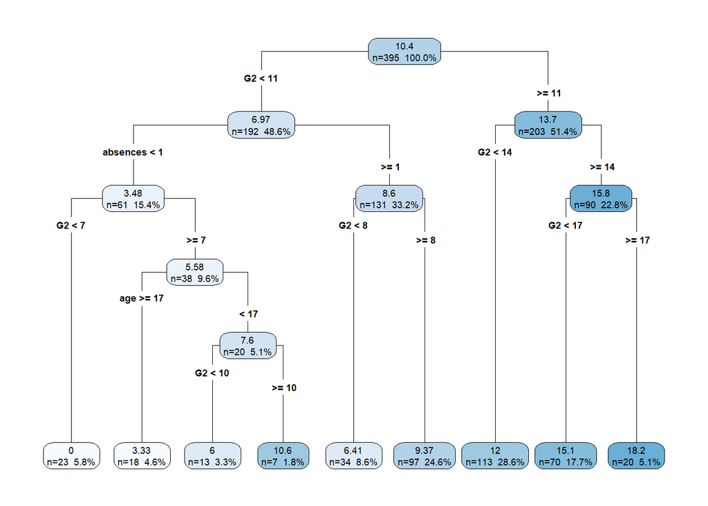

```r
library(rpart)
library(rpart.plot)

set.seed(42)
sp.tree = rpart(G3 ~ ., data=sp)

rpart.plot(sp.tree, digits = 3, type=4, extra=101)
```

### 2.1.1 Variable Importance

The `G2` factor shows up in a lot of the splits, which makes sense. Your previous grade in a class is probably a good predictor of your final grade. Print the variable importance for your model with `MyTree$variable.importance` and comment on the results.

```r
sp.tree$variable.importance
```

```
##         G2         G1   absences   failures       Medu      goout  schoolsup
## 6293.74681 4293.64396 1156.54787 1036.91071  736.56843  658.02505  623.96794
##     health        age       Fedu  studytime    address       Fjob   romantic
##  239.28059  172.46316  125.46295  116.33477   96.94564   59.85455   47.90643
## activities    Pstatus    famsize   freetime
##   27.16735   15.36508   13.58367    7.68254
```

```r
# after G2, G1 is the next most important, then it drops off rapidly to
# absences and failures
```

Plotting the variable importance would be a nice touch.

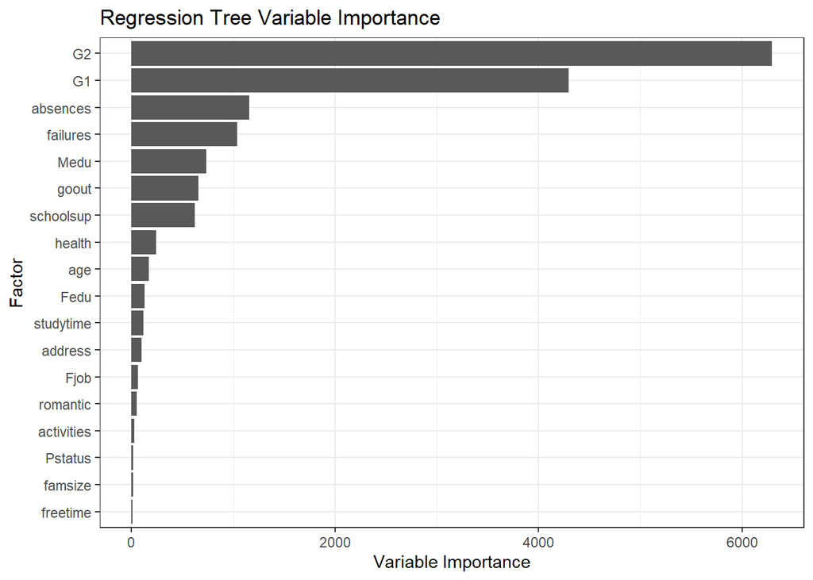

```r
library(tidyverse)

ggplot() +
  geom_col(aes(x=factor(names(sp.tree$variable.importance),
                        levels=rev(names(sp.tree$variable.importance))),
               y=sp.tree$variable.importance)) +
  coord_flip() +
  ylab("Variable Importance") +
  xlab("Factor") +
  ggtitle("Regression Tree Variable Importance") +
  theme_bw()
```

### 2.1.2 Prune

Prune the tree using the 1se rule. First use `plotcp()` to determine the number of splits to allow.

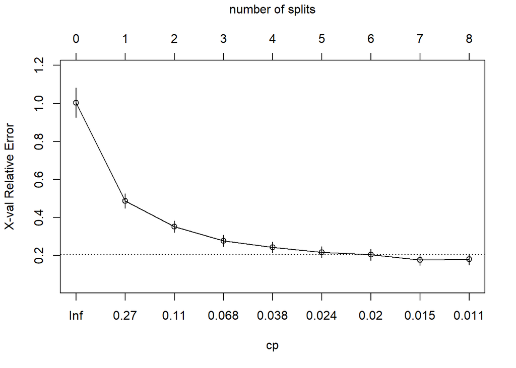

```r
plotcp(sp.tree, upper = "splits")
```

Now find the `CP` associated with the `nsplit`.

```r
printcp(sp.tree)
```

```
##
## Regression tree:
## rpart(formula = G3 ~ ., data = sp)
##
## Variables actually used in tree construction:
## [1] absences age      G2
##
## Root node error: 8269.9/395 = 20.936
##
## n= 395
##
##         CP nsplit rel error  xerror     xstd
## 1 0.534970      0   1.00000 1.00373 0.077893
## 2 0.132323      1   0.46503 0.48757 0.038415
## 3 0.085040      2   0.33271 0.35220 0.030272
## 4 0.053924      3   0.24767 0.27731 0.029547
## 5 0.026661      4   0.19374 0.24375 0.028554
## 6 0.020854      5   0.16708 0.21787 0.030164
## 7 0.018580      6   0.14623 0.20421 0.029435
## 8 0.011498      7   0.12765 0.17742 0.028167
## 9 0.010000      8   0.11615 0.17998 0.029249
```

Choose a `CP` value slightly greater than the one you identified above, and use it to prune your tree. Then, plot the pruned tree.

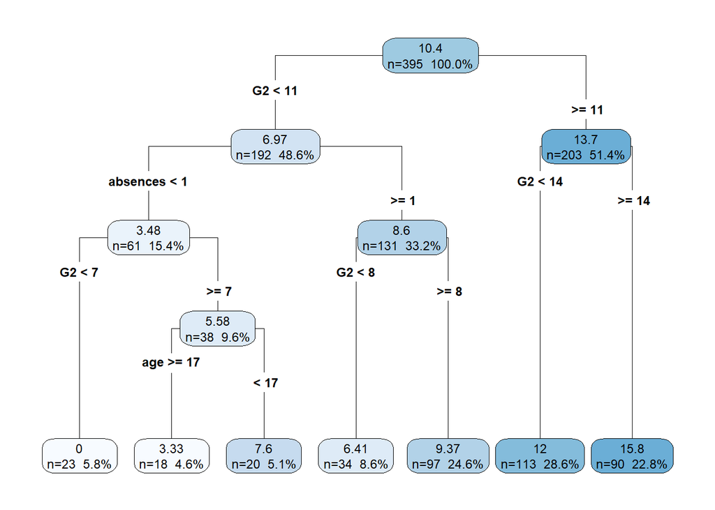

```r
sp.prune = rpart(G3~., cp = 0.019, data = sp)

rpart.plot(sp.prune, digits = 3, type=4, extra=101)
```

### 2.1.3 Deviance

How much deviance do your unpruned and pruned trees explain?

```r
# unpruned deviance explained
(1-0.11615)*100
```

```
## [1] 88.385
```

```r
# pruned
(1-0.14623)*100
```

```
## [1] 85.377
```

```r
# 0.14623 comes from the relerror column at nsplit = 6
```

### 2.1.4 Drop G1 and G2

Grow a new tree without `G1` and `G2`, print the variable importance, and comment on the results.

```r
sp.tree2 = rpart(G3~., data = sp %>% select(-G1, -G2), model=TRUE)

sp.tree2$variable.importance
```

```
##   absences   failures       Mjob        age   freetime        sex   guardian
## 1409.05834 1042.74339  255.26034  251.62479  223.46632  200.11038  163.68258
##     health       Fjob     reason     higher traveltime      goout  studytime
##  158.05067  127.97006  124.41681   88.47555   72.68561   55.43523   54.09615
##       Medu   romantic       Fedu     school     famrel    address       Walc
##   47.42399   38.05084   35.22784   31.86624   30.35037   22.91889   21.55806
##       Dalc     famsup
##   20.42343   13.09651
```

```r
# the first two are the same, but then it differs. Also, a lot
# more variables are included in this tree.
```

### 2.1.5 Deviance

Without pruning the tree, how much variance does the tree explain without `G1` and `G2`?

```r
printcp(sp.tree2)
```

```
##
## Regression tree:
## rpart(formula = G3 ~ ., data = sp %>% select(-G1, -G2), model = TRUE)
##
## Variables actually used in tree construction:
## [1] absences failures Fjob     freetime health   Mjob     reason   sex
##
## Root node error: 8269.9/395 = 20.936
##
## n= 395
##
##         CP nsplit rel error  xerror     xstd
## 1 0.126089      0   1.00000 1.00446 0.077948
## 2 0.114259      1   0.87391 0.92353 0.073896
## 3 0.023363      2   0.75965 0.76935 0.068411
## 4 0.014540      3   0.73629 0.92354 0.081112
## 5 0.012885     10   0.63404 0.98812 0.083751
## 6 0.010000     13   0.59538 0.99186 0.085328
```

```r
# deviance explained
(1-0.59538)*100
```

```
## [1] 40.462
```

### 2.1.6 Linear Model

Fit and summarize a linear model and consider how you might go about eliminating predictors and developing a good linear model fit.

```r
summary(lm(G3~., data=sp))
```

```
##
## Call:
## lm(formula = G3 ~ ., data = sp)
##
## Residuals:
##     Min      1Q  Median      3Q     Max
## -7.9339 -0.5532  0.2680  0.9689  4.6461
##
## Coefficients:
##                   Estimate Std. Error t value Pr(>|t|)
## (Intercept)      -1.115488   2.116958  -0.527 0.598573
## schoolMS          0.480742   0.366512   1.312 0.190485
## sexM              0.174396   0.233588   0.747 0.455805
## age              -0.173302   0.100780  -1.720 0.086380 .
## addressU          0.104455   0.270791   0.386 0.699922
## famsizeLE3        0.036512   0.226680   0.161 0.872128
## PstatusT         -0.127673   0.335626  -0.380 0.703875
## Medu              0.129685   0.149999   0.865 0.387859
## Fedu             -0.133940   0.128768  -1.040 0.298974
## Mjobhealth       -0.146426   0.518491  -0.282 0.777796
## Mjobother         0.074088   0.332044   0.223 0.823565
## Mjobservices      0.046956   0.369587   0.127 0.898973
## Mjobteacher      -0.026276   0.481632  -0.055 0.956522
## Fjobhealth        0.330948   0.666601   0.496 0.619871
## Fjobother        -0.083582   0.476796  -0.175 0.860945
## Fjobservices     -0.322142   0.493265  -0.653 0.514130
## Fjobteacher      -0.112364   0.601448  -0.187 0.851907
## reasonhome       -0.209183   0.256392  -0.816 0.415123
## reasonother       0.307554   0.380214   0.809 0.419120
## reasonreputation  0.129106   0.267254   0.483 0.629335
## guardianmother    0.195741   0.252672   0.775 0.439046
## guardianother     0.006565   0.463650   0.014 0.988710
## traveltime        0.096994   0.157800   0.615 0.539170
## studytime        -0.104754   0.134814  -0.777 0.437667
## failures         -0.160539   0.161006  -0.997 0.319399
## schoolsupyes      0.456448   0.319538   1.428 0.154043
## famsupyes         0.176870   0.224204   0.789 0.430710
## paidyes           0.075764   0.222100   0.341 0.733211
## activitiesyes    -0.346047   0.205938  -1.680 0.093774 .
## nurseryyes       -0.222716   0.254184  -0.876 0.381518
## higheryes         0.225921   0.500398   0.451 0.651919
## internetyes      -0.144462   0.287528  -0.502 0.615679
## romanticyes      -0.272008   0.219732  -1.238 0.216572
## famrel            0.356876   0.114124   3.127 0.001912 **
## freetime          0.047002   0.110209   0.426 0.670021
## goout             0.012007   0.105230   0.114 0.909224
## Dalc             -0.185019   0.153124  -1.208 0.227741
## Walc              0.176772   0.114943   1.538 0.124966
## health            0.062995   0.074800   0.842 0.400259
## absences          0.045879   0.013412   3.421 0.000698 ***
## G1                0.188847   0.062373   3.028 0.002645 **
## G2                0.957330   0.053460  17.907  < 2e-16 ***
## ---
## Signif. codes:  0 '***' 0.001 '**' 0.01 '*' 0.05 '.' 0.1 ' ' 1
##
## Residual standard error: 1.901 on 353 degrees of freedom
## Multiple R-squared:  0.8458, Adjusted R-squared:  0.8279
## F-statistic: 47.21 on 41 and 353 DF,  p-value: < 2.2e-16
```

## 2.2 Random Forest

Perform regression using a random forest and with all predictors (including `G1` and `G2`). How much deviance does the random forest explain?

```r
library(randomForest)
set.seed(42)

sp.rf<- randomForest(G3~., importance=TRUE, data=sp)
sp.rf
```

```
##
## Call:
##  randomForest(formula = G3 ~ ., data = sp, importance = TRUE)
##                Type of random forest: regression
##                      Number of trees: 500
## No. of variables tried at each split: 10
##
##           Mean of squared residuals: 3.119319
##                     % Var explained: 85.1
```

### 2.2.1 Variable Importance

Plot the variable importance for the random forest model.

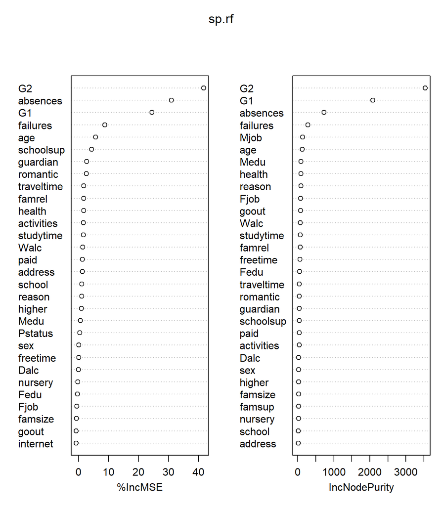

```r
varImpPlot(sp.rf)
```

# 3 Random Forest Classification

Download the glass data set from the UC-Irvine repository. This will save you some typing:

```
# glass=read.csv('https://archive.ics.uci.edu/ml/machine-learning-databases/glass/glass.data',
#                col.names=c("ID", "RI", "Na", "Mg", "Al", "Si", "K", "Ca", "Ba", "Fe", "Type"),
#                header=F, colClasses=c(rep("numeric", 10), "factor"))
```

As indicated on the repository’s website,

> The study of classification of types of glass was motivated by criminological investigation. At the scene of the crime, the glass left can be used as evidence…if it is correctly identified!

```r
glass=read.csv('https://archive.ics.uci.edu/ml/machine-learning-databases/glass/glass.data',
               col.names=c("ID", "RI", "Na", "Mg", "Al", "Si", "K", "Ca", "Ba", "Fe", "Type"),
               header=F, colClasses=c(rep("numeric", 10), "factor"))
```

## 3.1 Train and Test Data Sets

Set a random number generator seed, and create a training and a test data set using an 80/20 split. **Important: Use the same seed that you used in the support vector classifier problem.** Either drop the `ID` column or just don’t include it when training your models.

```r
# set the seed
set.seed(42)

# create training set
train = sample(1:nrow(glass), nrow(glass)*0.8, replace=FALSE)
glass_train = glass %>% slice(train) %>% select(-ID)

# create test set
glass_test = glass %>% slice(-train) %>% select(-ID)
```

## 3.2 Grow a Forest

Fit the model on the training set using default hyperparameters and print the resulting object.

```r
glass.rf = randomForest(Type ~ ., data = glass_train)
print(glass.rf)
```

```
##
## Call:
##  randomForest(formula = Type ~ ., data = glass_train)
##                Type of random forest: classification
##                      Number of trees: 500
## No. of variables tried at each split: 3
##
##         OOB estimate of  error rate: 19.3%
## Confusion matrix:
##    1  2 3 5 6  7 class.error
## 1 43  6 2 0 0  0   0.1568627
## 2  8 56 0 0 1  0   0.1384615
## 3  7  2 5 0 0  0   0.6428571
## 5  0  2 0 6 0  1   0.3333333
## 6  0  1 0 0 6  0   0.1428571
## 7  0  3 0 0 0 22   0.1200000
```

## 3.3 Plot

Plot the randomForest object to see if it stabilized before 500 trees.

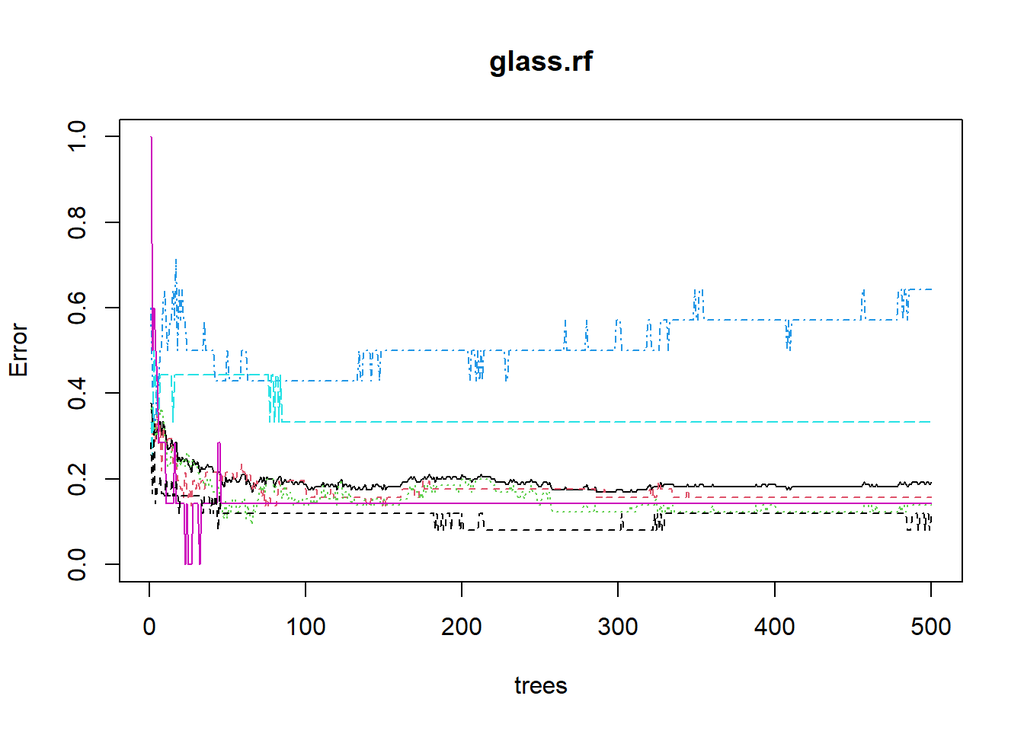

```r
plot(glass.rf)
```

## 3.4 Confusion Matrix and Accuracy

Make predictions on the test set, produce a confusion matrix, and calculate the prediction accuracy. How does it compare the support vector classifier from the previous problem set?

```r
# confusion matrix
rf.tab = table(predict(glass.rf, newdata=glass_test %>% select(-Type)), glass_test$Type)
rf.tab
```

```
##
##      1  2  3  5  6  7
##   1 15  2  1  0  0  1
##   2  1  6  2  0  1  0
##   3  3  1  0  0  0  0
##   5  0  1  0  4  0  0
##   6  0  0  0  0  1  0
##   7  0  1  0  0  0  3
```

```r
# accuracy
sum(diag(rf.tab)) / nrow(glass_test)
```

```
## [1] 0.6744186
```

```r
# the accuracy is slightly worse than the radial kernel SVC but better than the linear kernel.
```